# Introduction to R

# R for Data Science

## Introduction

We will be using the [R programming language](https://cran.r-project.org/) for all our analysis. You will learn R and statistics simultaneously. We will by installing R and RStudio, then covering some basics.

Although R is technically a programming language, it was developed specifically for analyzing data. We will therefore teach R in the context of analyzing data rather than as one would teach a programming language. As a result, we will be learning some data analysis concepts along the way. For those with limited programming experinece we highly recommend you complete one of the following R programming courses:

- DataCamp’s [R course](https://www.datacamp.com/courses/free-introduction-to-r)
- edX’s [Introduction to R Programming](https://www.edx.org/course/introduction-r-programming-microsoft-dat204x-0)

Below we include a broader list of resources for learning R.

## Installing R

The first step is to install R. You can download and install R from the [Comprehensive R Archive Network](https://cran.r-project.org/) (CRAN). It is relatively straightforward, but if you need further help you can try the following resources:

- [Installing R on Windows](https://github.com/genomicsclass/windows#installing-r)
- [Installing R on Mac](http://youtu.be/Icawuhf0Yqo)
- [Installing R on Ubuntu](http://cran.r-project.org/bin/linux/ubuntu/README)

## Installing RStudio

The next step is to install RStudio, a program for viewing and running R scripts. Technically you can run all the code shown here without installing RStudio, but we highly recommend this integrated development environment (IDE). Instructions are [here](http://www.rstudio.com/products/rstudio/download/) and for Windows we have special [instructions](https://github.com/genomicsclass/windows).

## The Console

Now that you have download and installed R you are ready to start working with data. Whichever approach you are using to interact with R, we recommend RStudio, you should identify the console.

When you type a line of code into the consult and hit enter the command gets *executed*. For example, try typine

```r
2+3
```

```
## [1] 5
```

We can also assign values to variables. Try the following

```r
x <- 2
y <- 3
x + y
```

```
## [1] 5
```

## The R ecosystem

When you download R from CRAN you get what we call *base* R. This includes several *functions* that are considered fundamental for data analysis. It also includes several example datasets. These datasets are particularly useful as examples when we are learning to use the available functions. You can see all the available dataset by executing the function `data` like this:

```r
data()
```

Because in R functions are objects, we need the two parenthesis to let R know that we want the function to be executed as opposed to showing us the code for the function. Type the following and note the difference:

```r
data
```

To see na example of functions at work, we will use to `co2` dataset to illustrate the function `plot`, one of the base functions. We can plot Mauna Loa Atmospheric CO2 Concentration versus data like this:

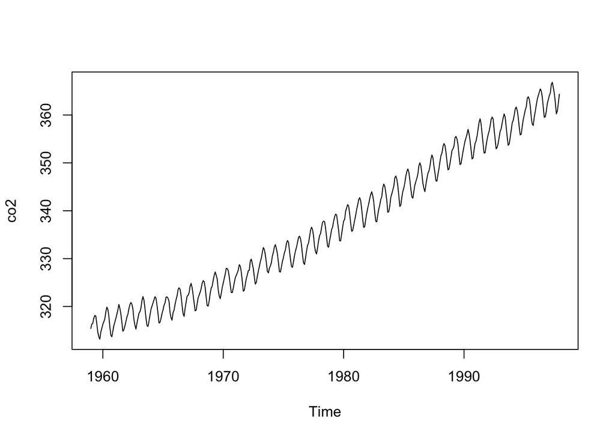

```r
plot(co2)
```

Note that R’s base functionality is bare bones. Note that data science applications are broad, the statistical toolbox is extensive, and most users need only a small fraction of all the available functionality. Therefore, a better approach is to make specific functionality available *on demand*. R does this using *packages*, also called *libraries*.

Some packages are considered popular enough that they are included with the base download. For example, the software implementing the method of survival analysis are in the `survival` package. To bring that functionality to your current session we type

```r
library(survival)
```

However, CRAN has over 4,000 packages that are not included in the base installation. You can install these using the `install.packages` function.

## Installing Packages

The first R command we will run is `install.packages`. R only includes a basic set of functions. It can do much more than this, but not everybody needs everything so we instead make some functions available via packages. Many of these functions are stored in CRAN where packages are vetted: they are checked for common errors and they must have a dedicated maintainer. There are other repositories, some with more vetting, such as [Bioconductor](http://www.bioconductor.org), and no vetting, such as GitHub. You can easily install CRAN packages from within R if you know the name of the packages. As an example, we are going to install the package `dplyr` which we use in our first data analysis examples:

```r
install.packages("dplyr")
```

We can then load the package into our R sessions using the `library` function:

```r
library(dplyr)
```

From now on you will see that we sometimes load packages without installing them. This is because once you install the package, it remains in place and only needs to be loaded with `library`. If you try to load a package and get an error, it probably means you need to install it first.

## Getting help

A key feuature you need to know about R is that you can get help for a function using `help` or `?`, like this:

```r
?install.packages
help("install.packages")
```

These pages are quite detailed and also include examples at the end.

## Comments

The hash character represents comments, so text following these characters is not interpreted:

```r
##This is just a comment
```

## Importing Data into R

Small datasets such as the one used as an example here are typically stored as Excel files. Although there are R packages designed to read Excel (xls) format, you generally want to avoid this and save files as comma delimited (Comma-Separated Value/CSV) or tab delimited (Tab-Separated Value/TSV/TXT) files. These plain-text formats are often easier for sharing, as commercial software is not required for viewing or working with the data.

We will start with a simple example dataset containing the [heights of students in our class](https://raw.githubusercontent.com/datasciencelabs/data/master/bio260-heights.csv)

The first step is to find the file containing your data and know its *path*.

#### Paths and the Working Directory

When you are working in R it is useful to know your *working directory*. This is the directory or folder in which R will save or look for files by default. You can see your working directory by typing:

```r
getwd()
```

You can also change your working directory using the function `setwd`. Or you can change it through RStudio by clicking on “Session”.

The functions that read and write files (there are several in R) assume you mean to look for files or write files in the working directory. Our recommended approach for beginners will have you reading and writing to the working directory. However, you can also type the [full path](http://www.computerhope.com/jargon/a/absopath.htm), which will work independently of the working directory.

#### Projects in RStudio

We find that the simplest way to organize yourself is to start a Project in RStudio (Click on “File” and “New Project”). When creating the project, you will select a folder to be associated with it. You can then download all your data into this folder. Your working directory will be this folder.

## Resources

Apart from the two courses lister above, there are many resources to help you familiarize yourself with the basics of programming and R syntax. One such tutorial is the [swirl](http://swirlstats.com/) tutorial, which teaches you R programming interactively, at your own pace and in the R console. Once you have R installed, you can install `swirl` and run it the following way:

```r
install.packages("swirl")
library(swirl)
swirl()
```

[try R](http://tryr.codeschool.com/) interactive class from Code School.

There are also many open and free resources and reference guides for R. Two examples are:

- [Quick-R](http://www.statmethods.net/): a quick online reference for data input, basic statistics and plots
- R reference card (PDF)[https://cran.r-project.org/doc/contrib/Short-refcard.pdf] by Tom Short

#### More advanced R Resources (from Roger Peng)

Available from CRAN (http://cran.r-project.org)

- An Introduction to R
- Writing R Extensions
- R Data Import/Export
- R Installation and Administration (mostly for building R from sources)
- R Internals (not for the faint of heart)

#### Some Useful Books on S/R

Standard texts

- Chambers (2008). *Software for Data Analysis*, Springer. (your textbook)
- Chambers (1998). *Programming with Data*, Springer.
- Venables & Ripley (2002). *Modern Applied Statistics with S*, Springer.
- Venables & Ripley (2000). *S Programming*, Springer.
- Pinheiro & Bates (2000). *Mixed-Effects Models in S and S-PLUS*, Springer.
- Murrell (2005). *R Graphics*, Chapman & Hall/CRC Press.

Other resources

- Springer has a series of books called *Use R!*.
- A longer list of books is at http://www.r-project.org/doc/bib/R-books.html